# Self Case Study - 1

## Customer Relationship Prediction - Appetency

```python
!pip install -U scikit-learn
```

```python
!pip install dython
```

```python
!pip install fast-ml
```

```python
import warnings
warnings.filterwarnings("ignore")

import numpy as np
import pandas as pd
from matplotlib import pyplot as plt
import seaborn as sns
from sklearn.preprocessing import OrdinalEncoder
from sklearn.manifold import TSNE
from sklearn.preprocessing import PolynomialFeatures

import missingno as msno
from dython import nominal

import pickle

from sklearn.cluster import DBSCAN, KMeans

from fast_ml.utilities import display_all
from fast_ml.feature_selection import get_duplicate_features

from sklearn.model_selection import train_test_split

from prettytable import PrettyTable

%matplotlib inline
```

### Loading data

```python
data = pd.read_csv('orange_small_train.data', sep = '\t')
```

```python
data.shape
```

```
(50000, 230)
```

```python
data.info()
```

```
<class 'pandas.core.frame.DataFrame'>
RangeIndex: 50000 entries, 0 to 49999
Columns: 230 entries, Var1 to Var230
dtypes: float64(191), int64(1), object(38)
memory usage: 87.7+ MB
```

#### There are total of 50k datapoints and each datapoint has 230 features.

```python
data.head()
```

|  | Var1 | Var2 | Var3 | Var4 | Var5 | Var6 | Var7 | Var8 | Var9 | Var10 | Var11 | Var12 | Var13 | Var14 | Var15 | Var16 | Var17 | Var18 | Var19 | Var20 | Var21 | Var22 | Var23 | Var24 | Var25 | Var26 | Var27 | Var28 | Var29 | … |
| --- | --- | --- | --- | --- | --- | --- | --- | --- | --- | --- | --- | --- | --- | --- | --- | --- | --- | --- | --- | --- | --- | --- | --- | --- | --- | --- | --- | --- | --- | --- |
| 0 | NaN | NaN | NaN | NaN | NaN | 1526.0 | 7.0 | NaN | NaN | NaN | NaN | NaN | 184.0 | NaN | NaN | NaN | NaN | NaN | NaN | NaN | 464.0 | 580.0 | NaN | 14.0 | 128.0 | NaN | NaN | 166.56 | NaN | … |
| 1 | NaN | NaN | NaN | NaN | NaN | 525.0 | 0.0 | NaN | NaN | NaN | NaN | NaN | 0.0 | NaN | NaN | NaN | NaN | NaN | NaN | NaN | 168.0 | 210.0 | NaN | 2.0 | 24.0 | NaN | NaN | 353.52 | NaN | … |
| 2 | NaN | NaN | NaN | NaN | NaN | 5236.0 | 7.0 | NaN | NaN | NaN | NaN | NaN | 904.0 | NaN | NaN | NaN | NaN | NaN | NaN | NaN | 1212.0 | 1515.0 | NaN | 26.0 | 816.0 | NaN | NaN | 220.08 | NaN | … |
| 3 | NaN | NaN | NaN | NaN | NaN | NaN | 0.0 | NaN | NaN | NaN | NaN | NaN | 0.0 | NaN | NaN | NaN | NaN | NaN | NaN | NaN | NaN | 0.0 | NaN | NaN | 0.0 | NaN | NaN | 22.08 | NaN | … |
| 4 | NaN | NaN | NaN | NaN | NaN | 1029.0 | 7.0 | NaN | NaN | NaN | NaN | NaN | 3216.0 | NaN | NaN | NaN | NaN | NaN | NaN | NaN | 64.0 | 80.0 | NaN | 4.0 | 64.0 | NaN | NaN | 200.00 | NaN | … |

5 rows × 230 columns

```python
data.describe()
```

|  | Var1 | Var2 | Var3 | Var4 | Var5 | Var6 | Var7 | Var8 | Var9 | Var10 | Var11 | Var12 | Var13 | Var14 | Var15 | Var16 | Var17 | Var18 | Var19 | Var20 | Var21 | Var22 | Var23 | Var24 | Var25 | Var26 | Var27 | Var28 | Var29 | … |
| --- | --- | --- | --- | --- | --- | --- | --- | --- | --- | --- | --- | --- | --- | --- | --- | --- | --- | --- | --- | --- | --- | --- | --- | --- | --- | --- | --- | --- | --- | --- |
| count | 702.000000 | 1241.000000 | 1240.000000 | 1579.000000 | 1.487000e+03 | 44471.000000 | 44461.000000 | 0.0 | 702.000000 | 1.487000e+03 | 1240.000000 | 558.000000 | 44461.000000 | 1240.000000 | 0.0 | 1487.000000 | 1579.000000 | 1579.000000 | 1579.000000 | 0.0 | 44471.000000 | 44991.000000 | 1487.000000 | 42770.000000 | 44991.000000 | 1487.000000 | 1487.000000 | 44989.000000 | 702.000000 | … |
| mean | 11.487179 | 0.004029 | 425.298387 | 0.125396 | 2.387933e+05 | 1326.437116 | 6.809496 | NaN | 48.145299 | 3.926057e+05 | 8.625806 | 16.071685 | 1249.688401 | 0.741935 | NaN | 120.239275 | 11.393287 | 7.215959 | 0.245092 | NaN | 234.518225 | 290.245382 | 7.535306 | 4.507926 | 96.827010 | 0.070612 | 0.028245 | 224.507669 | 0.022792 | … |
| std | 40.709951 | 0.141933 | 4270.193518 | 1.275481 | 6.441259e+05 | 2685.693668 | 6.326053 | NaN | 154.777855 | 9.280896e+05 | 2.869558 | 64.185508 | 2794.954874 | 3.714316 | NaN | 72.386254 | 49.493856 | 34.415427 | 1.781497 | NaN | 565.560147 | 704.489990 | 49.449472 | 9.928819 | 214.318283 | 0.528836 | 0.247210 | 98.520240 | 0.212436 | … |
| min | 0.000000 | 0.000000 | 0.000000 | 0.000000 | 0.000000e+00 | 0.000000 | 0.000000 | NaN | 0.000000 | 0.000000e+00 | 8.000000 | 0.000000 | 0.000000 | 0.000000 | NaN | 0.000000 | 0.000000 | 0.000000 | 0.000000 | NaN | 0.000000 | 0.000000 | 0.000000 | 0.000000 | 0.000000 | 0.000000 | 0.000000 | -66.880000 | 0.000000 | … |
| 25% | 0.000000 | 0.000000 | 0.000000 | 0.000000 | 0.000000e+00 | 518.000000 | 0.000000 | NaN | 4.000000 | 0.000000e+00 | 8.000000 | 0.000000 | 0.000000 | 0.000000 | NaN | 51.920000 | 0.000000 | 0.000000 | 0.000000 | NaN | 112.000000 | 135.000000 | 0.000000 | 0.000000 | 16.000000 | 0.000000 | 0.000000 | 166.560000 | 0.000000 | … |
| 50% | 0.000000 | 0.000000 | 0.000000 | 0.000000 | 0.000000e+00 | 861.000000 | 7.000000 | NaN | 20.000000 | 0.000000e+00 | 8.000000 | 0.000000 | 232.000000 | 0.000000 | NaN | 131.080000 | 0.000000 | 0.000000 | 0.000000 | NaN | 144.000000 | 180.000000 | 0.000000 | 2.000000 | 48.000000 | 0.000000 | 0.000000 | 220.080000 | 0.000000 | … |
| 75% | 16.000000 | 0.000000 | 0.000000 | 0.000000 | 1.187425e+05 | 1428.000000 | 7.000000 | NaN | 46.000000 | 2.628630e+05 | 8.000000 | 16.000000 | 1604.000000 | 0.000000 | NaN | 170.080000 | 10.000000 | 0.000000 | 0.000000 | NaN | 228.000000 | 285.000000 | 5.000000 | 6.000000 | 112.000000 | 0.000000 | 0.000000 | 266.400000 | 0.000000 | … |
| max | 680.000000 | 5.000000 | 130668.000000 | 27.000000 | 6.048550e+06 | 131761.000000 | 140.000000 | NaN | 2300.000000 | 1.232559e+07 | 40.000000 | 1184.000000 | 197872.000000 | 48.000000 | NaN | 434.920000 | 1220.000000 | 948.000000 | 27.000000 | NaN | 36272.000000 | 45340.000000 | 1555.000000 | 494.000000 | 13168.000000 | 9.000000 | 4.000000 | 5158.560000 | 2.000000 | … |

8 rows × 192 columns

```python
appetency_labels = pd.read_csv('orange_small_train_appetency.labels', header = None,names = ['Appetency'])
```

```python
appetency_labels.head()
```

|  | Appetency |
| --- | --- |
| 0 | -1 |
| 1 | -1 |
| 2 | -1 |
| 3 | -1 |
| 4 | -1 |

```python
appetency_labels['Appetency'] = appetency_labels.Appetency.apply(lambda x: 0 if (x == -1) else x)
```

```python
appetency_labels.shape
```

```
(50000, 1)
```

### Splitting data into train and test before data analysis

```python
X_train_appetency, X_test_appetency, y_train_appetency, y_test_appetency = train_test_split(data,appetency_labels, test_size = 0.2, stratify = appetency_labels)
```

### EDA

#### Class distribution

```python
def plot_class_dist(x, data):
    sns.countplot(x = x,data =  data)
    plt.title('{} class label value counts'.format(x))
    plt.show()
```

##### Appetency

```python
y_train_appetency.value_counts()
```

```
Appetency
0            39288
1              712
dtype: int64
```

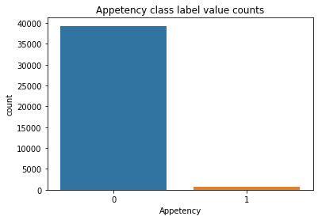

```python
plot_class_dist('Appetency', y_train_appetency)
```

Observation:

- Data w.r.t appetency label is highly imbalanced.

#### Counting total NaNs for each feature

```python
print('Number of features which only have NaNs present: ',(X_train_appetency.isna().sum() == X_train_appetency.shape[0]).sum())
```

```
Number of features which only have NaNs present:  18
```

```python
all_nan_columns = np.array(X_train_appetency.columns[X_train_appetency.isna().sum() == X_train_appetency.shape[0]])
```

```python
print('Number of features which do not countain NaNs:',(X_train_appetency.notna().sum() == X_train_appetency.shape[0]).sum())
```

```
Number of features which do not countain NaNs: 19
```

```python
not_nan_columns = np.array(X_train_appetency.columns[X_train_appetency.notna().sum() == X_train_appetency.shape[0]])
```

```python
not_nan_columns
```

```
array(['Var57', 'Var73', 'Var113', 'Var193', 'Var195', 'Var196', 'Var198',
       'Var204', 'Var207', 'Var210', 'Var211', 'Var212', 'Var216',
       'Var220', 'Var221', 'Var222', 'Var226', 'Var227', 'Var228'],
      dtype=object)
```

```python
X_train_appetency.dtypes[not_nan_columns]
```

```
Var57     float64
Var73       int64
Var113    float64
Var193     object
Var195     object
Var196     object
Var198     object
Var204     object
Var207     object
Var210     object
Var211     object
Var212     object
Var216     object
Var220     object
Var221     object
Var222     object
Var226     object
Var227     object
Var228     object
dtype: object
```

**Observation:**

```
- Out of 19 columns which do not have any missing data, 3 are numerical and 16 are categorical.
```

```python
#https://stackoverflow.com/questions/26266362/how-to-count-the-nan-values-in-a-column-in-pandas-dataframe
nan_count_array = []
for i in X_train_appetency.columns:
    nan_count = X_train_appetency[i].isna().sum()
    nan_count_array.append(nan_count)
```

```python
#to-do: tabular form
x = PrettyTable()
x.add_column('Features', list(X_train_appetency.columns))
x.add_column('Number of NaNs',nan_count_array)
```

```python
print(x)
```

```
+----------+----------------+
| Features | Number of NaNs |
+----------+----------------+
|   Var1   |     39427      |
|   Var2   |     39008      |
|   Var3   |     39009      |
|   Var4   |     38717      |
|   Var5   |     38850      |
|   Var6   |      4417      |
|   Var7   |      4421      |
|   Var8   |     40000      |
|   Var9   |     39427      |
|  Var10   |     38850      |
|  Var11   |     39009      |
|  Var12   |     39543      |
|  Var13   |      4421      |
|  Var14   |     39009      |
|  Var15   |     40000      |
|  Var16   |     38850      |
|  Var17   |     38717      |
|  Var18   |     38717      |
|  Var19   |     38717      |
|  Var20   |     40000      |
|  Var21   |      4417      |
|  Var22   |      3998      |
|  Var23   |     38850      |
|  Var24   |      5779      |
|  Var25   |      3998      |
|  Var26   |     38850      |
|  Var27   |     38850      |
|  Var28   |      3999      |
|  Var29   |     39427      |
|  Var30   |     39427      |
|  Var31   |     40000      |
|  Var32   |     40000      |
|  Var33   |     39341      |
|  Var34   |     39008      |
|  Var35   |      3998      |
|  Var36   |     39008      |
|  Var37   |     38717      |
```

[output cut: 179 more lines]

```
|  Var217  |      570       |
|  Var218  |      570       |
|  Var219  |      4167      |
|  Var220  |       0        |
|  Var221  |       0        |
|  Var222  |       0        |
|  Var223  |      4167      |
|  Var224  |     39338      |
|  Var225  |     20842      |
|  Var226  |       0        |
|  Var227  |       0        |
|  Var228  |       0        |
|  Var229  |     22671      |
|  Var230  |     40000      |
+----------+----------------+
```

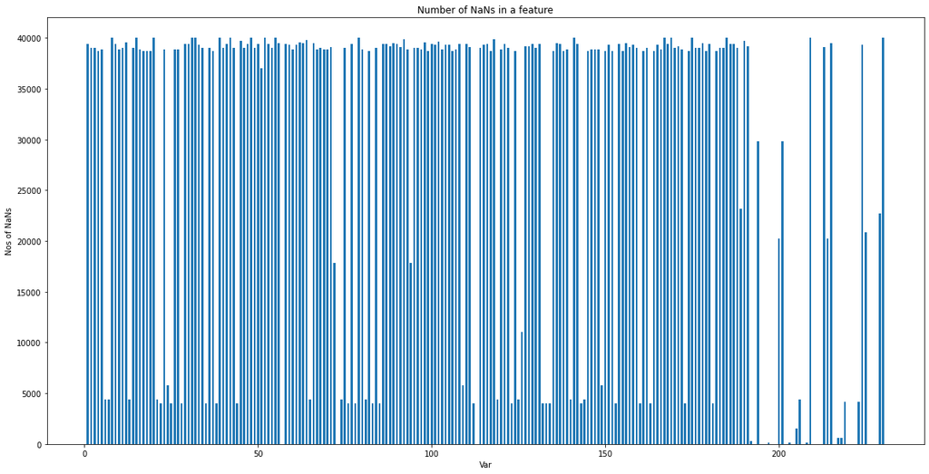

```python
fig = plt.figure(figsize = (20, 10))
plt.bar(range(1,X_train_appetency.shape[1]+1), height = nan_count_array, width = 0.6,data = nan_count_array)
plt.xlabel('Var')
plt.ylabel('Nos of NaNs')
plt.title('Number of NaNs in a feature')
plt.show()
```

Observation:

#### Unique value counts for Categorical features

- Categorical features ranges from Var191 to Var230
- We'll see the the unique values that each feature holds. Based on the count, we'll decide which categorical encoding to choose.
- If the value count per feature is high, then choosing OHE will result in highly sparse and large vectors.

```python
X_train_appetency.iloc[:,190:].head()
```

|  | Var191 | Var192 | Var193 | Var194 | Var195 | Var196 | Var197 | Var198 | Var199 | Var200 | Var201 | Var202 | Var203 | Var204 | Var205 | Var206 | Var207 | Var208 | Var209 | Var210 | Var211 | Var212 | Var213 | Var214 | Var215 | Var216 | Var217 | Var218 | Var219 | … |
| --- | --- | --- | --- | --- | --- | --- | --- | --- | --- | --- | --- | --- | --- | --- | --- | --- | --- | --- | --- | --- | --- | --- | --- | --- | --- | --- | --- | --- | --- | --- |
| 1660 | NaN | 9rAq9at_88 | rEUOq2QD1qfkRr6qpua | NaN | taul | 1K8T | lK27 | fhk21Ss | Tg7jjBB | 60P9wLk | NaN | ympL | 9_Y1 | KfYH | VpdQ | sYC_ | 7M47J5GA0pTYIFxg5uy | kIsH | NaN | g5HH | L84s | tbewxY_YSo | NaN | 5zAeq8m | NaN | XTbq0YX | wXGg | cJvF | FzaX | … |
| 24237 | NaN | Qu0TmBQZiT | RO12 | NaN | LfvqpCtLOY | 1K8T | iJ4u | eQgxutV | n1zVHpT8NN | NaN | NaN | 9JQA | 9_Y1 | TjV7 | sJzTlal | IYzP | me75fM6ugJ | kIsH | NaN | uKAI | Mtgm | NhsEn4L | NaN | NaN | NaN | kq00nJM | TDYB | UYBR | NaN | … |
| 1673 | NaN | zcROj1KVEH | RO12 | NaN | taul | 1K8T | 0Y9G | T7ckueW | y2LIM01bE1 | NaN | NaN | uFNB | 9_Y1 | jdbz | 09_Q | zm5i | me75fM6ugJ | kIsH | NaN | uKAI | Mtgm | NhsEn4L | NaN | NaN | NaN | mAjbk_S | ijVe | UYBR | FzaX | … |
| 30043 | r__I | dRavyx7ejg | RO12 | NaN | taul | 1K8T | SzjZ | z7269e2 | r83_sZi | NaN | NaN | oe6C | 9_Y1 | xSqs | VpdQ | NaN | DHn_WUyBhW_whjA88g9bvA64_ | kIsH | NaN | uKAI | L84s | CrNX | NaN | NaN | NaN | NGZ_12K | 3zCM | cJvF | NaN | … |
| 11297 | NaN | 1KSTmBQxul | 2Knk1KF | SEuy | taul | 1K8T | PGNs | eDd7wZ4 | glRBFJT8NN | 1qt7Yyi | smXZ | SxPy | 9_Y1 | TjV7 | VpdQ | y6dw | me75fM6ugJ | kIsH | NaN | uKAI | L84s | XfqtO3UdzaXh_ | NaN | OSsNfBq | NaN | XTbPUYD | DKzw | UYBR | FzaX | … |

```python
X_train_appetency.iloc[:,190:].nunique(axis = 0,dropna = False)
```

```
Var191        2
Var192      356
Var193       50
Var194        4
Var195       23
Var196        4
Var197      224
Var198     3879
Var199     4413
Var200    13351
Var201        3
Var202     5532
Var203        5
Var204      100
Var205        4
Var206       22
Var207       13
Var208        3
Var209        1
Var210        6
Var211        2
Var212       80
Var213        2
Var214    13351
Var215        2
Var216     1835
Var217    12474
Var218        3
Var219       23
Var220     3879
Var221        7
Var222     3879
Var223        5
Var224        2
Var225        4
Var226       23
Var227        7
Var228       30
Var229        5
Var230        1
dtype: int64
```

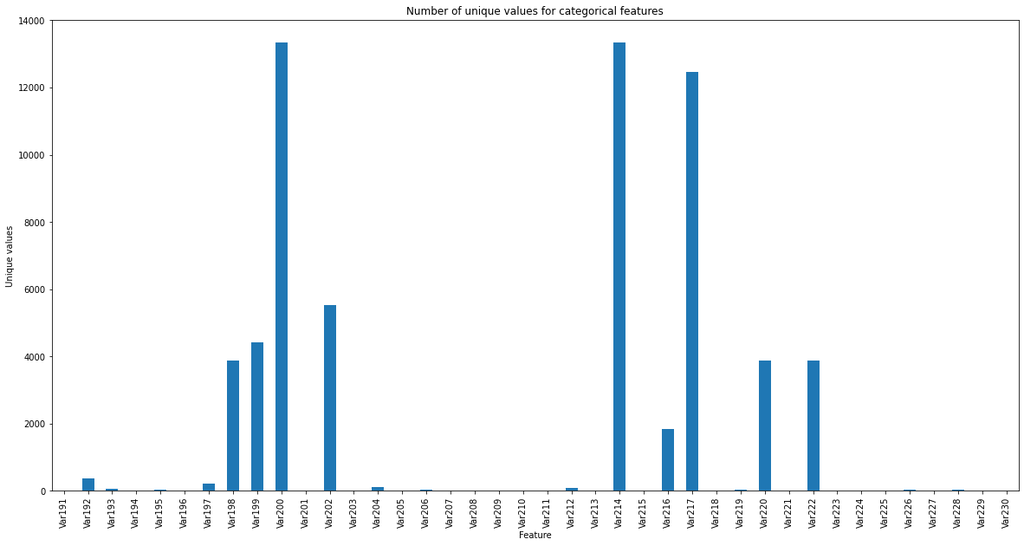

```python
#https://www.geeksforgeeks.org/how-to-count-distinct-values-of-a-pandas-dataframe-column/
fig = plt.figure(figsize = (20, 10))
X_train_appetency.iloc[:,190:].nunique(axis = 0,dropna = False).plot(kind = 'bar')
plt.title('Number of unique values for categorical features')
plt.xlabel('Feature')
plt.ylabel('Unique values')
plt.show()
```

##### Observation:

- 20 out of 40 feature have unique value count under 10.
- 9 features have unique value count which spans in range of 1000s

Although half of the categorical features have unique value count under 10, the other half has unique value counts in 1000s. It'll not be wise to apply OHE here as it'll create sparse vector having len in 1000s <font color = 'red'>The encoding method depends on the algorithm under consideration. For instance, LR works pretty well with high dimentional data. OHE could give a good score in this case. But the same might not be suitable for algorithms that are affected by curse of dimensionality like KNN. Also, it might not work well on tree based models.</font>

#### Numerical range for class label

Since the number of numerical features are 190, we'll only look into range of few features.

```python
X_train_appetency.iloc[:,20:30].head()
```

|  | Var21 | Var22 | Var23 | Var24 | Var25 | Var26 | Var27 | Var28 | Var29 | Var30 |
| --- | --- | --- | --- | --- | --- | --- | --- | --- | --- | --- |
| 1660 | 96.0 | 120.0 | NaN | 2.0 | 8.0 | NaN | NaN | 100.32 | NaN | NaN |
| 24237 | 12.0 | 15.0 | NaN | 0.0 | 24.0 | NaN | NaN | 238.72 | NaN | NaN |
| 1673 | 84.0 | 105.0 | NaN | 12.0 | 8.0 | NaN | NaN | 166.56 | NaN | NaN |
| 30043 | NaN | NaN | NaN | NaN | NaN | NaN | NaN | NaN | NaN | NaN |
| 11297 | 368.0 | 460.0 | NaN | 6.0 | 160.0 | NaN | NaN | 233.44 | NaN | NaN |

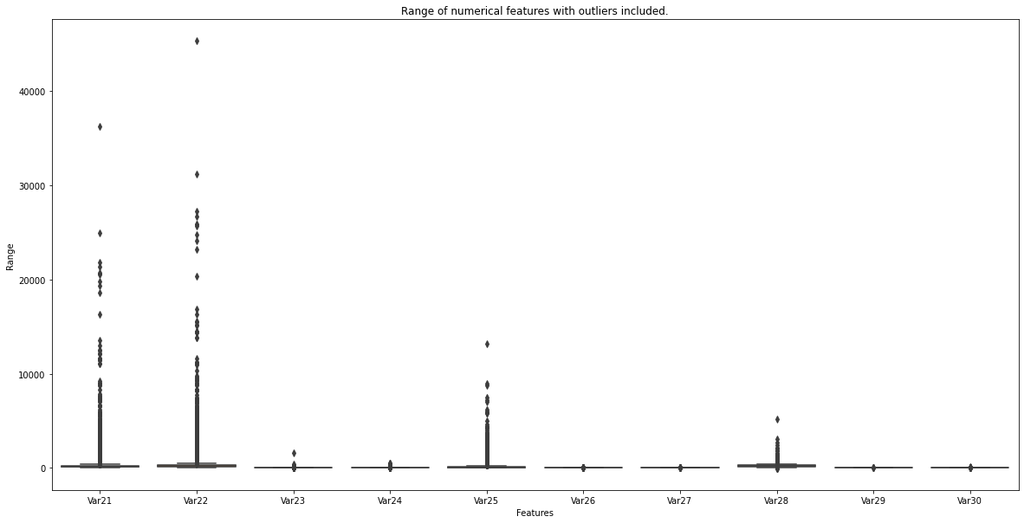

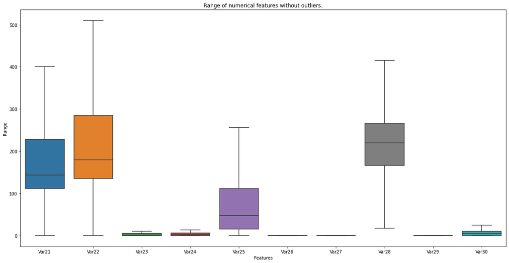

```python
# https://www.mikulskibartosz.name/how-to-remove-outliers-from-seaborn-boxplot-charts/
fig = plt.figure(figsize = (20, 10))
sns.boxplot(data = X_train_appetency.iloc[:,20:30])
plt.title('Range of numerical features with outliers included.')
plt.xlabel('Features')
plt.ylabel('Range')
plt.show()
fig = plt.figure(figsize = (20, 10))
sns.boxplot(data = X_train_appetency.iloc[:,20:30],showfliers = False)
plt.title('Range of numerical features without outliers.')
plt.xlabel('Features')
plt.ylabel('Range')
plt.show()
```

##### Observation:

- All features have different range.
- Var23 and Var24 have similar range.

#### Checking for pattern in missing values

```python
#https://towardsdatascience.com/missing-data-cfd9dbfd11b7
#https://towardsdatascience.com/all-about-missing-data-handling-b94b8b5d2184
#https://towardsdatascience.com/using-the-missingno-python-library-to-identify-and-visualise-missing-data-prior-to-machine-learning-34c8c5b5f009
#https://github.com/ResidentMario/missingno
```

##### We'll check whether the NaNs value occur w.r.t a specific class or not

```python
data_with_labels = pd.concat([X_train_appetency,y_train_appetency],axis = 1)
```

```python
#https://stackoverflow.com/questions/53947196/groupby-class-and-count-missing-values-in-features
#https://stackoverflow.com/questions/39454542/divide-two-dataframes-with-python
# Percentage of NaNs w.r.t class
data_with_labels.isna().groupby(data_with_labels.Appetency).sum().div(data_with_labels.Appetency.value_counts(),axis = 0) * 100
```

| Appetency | Var1 | Var2 | Var3 | Var4 | Var5 | Var6 | Var7 | Var8 | Var9 | Var10 | Var11 | Var12 | Var13 | Var14 | Var15 | Var16 | Var17 | Var18 | Var19 | Var20 | Var21 | Var22 | Var23 | Var24 | Var25 | Var26 | Var27 | Var28 | Var29 | … |
| --- | --- | --- | --- | --- | --- | --- | --- | --- | --- | --- | --- | --- | --- | --- | --- | --- | --- | --- | --- | --- | --- | --- | --- | --- | --- | --- | --- | --- | --- | --- |
| 0 | 98.579719 | 97.541234 | 97.543779 | 96.808186 | 97.118713 | 10.995724 | 11.003360 | 100.0 | 98.579719 | 97.118713 | 97.543779 | 98.869884 | 11.003360 | 97.543779 | 100.0 | 97.118713 | 96.808186 | 96.808186 | 96.808186 | 100.0 | 10.995724 | 9.952148 | 97.118713 | 14.393708 | 9.952148 | 97.118713 | 97.118713 | 9.954694 | 98.579719 | … |
| 1 | 97.893258 | 96.348315 | 96.348315 | 95.926966 | 97.471910 | 13.623596 | 13.764045 | 100.0 | 97.893258 | 97.471910 | 96.348315 | 98.174157 | 13.764045 | 96.348315 | 100.0 | 97.471910 | 95.926966 | 95.926966 | 95.926966 | 100.0 | 13.623596 | 12.359551 | 97.471910 | 17.415730 | 12.359551 | 97.471910 | 97.471910 | 12.359551 | 97.893258 | … |

2 rows × 231 columns

##### Observation:

- NaN value doesn't occur for specific class.
- Percetage of NaN is uniform across classe.

#### Dropping columns with only NaNs value present

```python
temp_data = X_train_appetency.drop(columns = all_nan_columns)
```

```python
#temp_data = temp_data.drop(columns = not_nan_columns)
```

```python
temp_data.shape
```

```
(40000, 212)
```

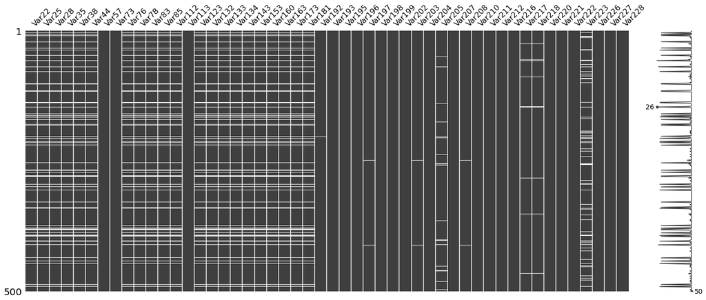

```python
filter_data = msno.nullity_filter(temp_data, filter='top',n = 50)
msno.matrix(filter_data.sample(500))
plt.show()
```

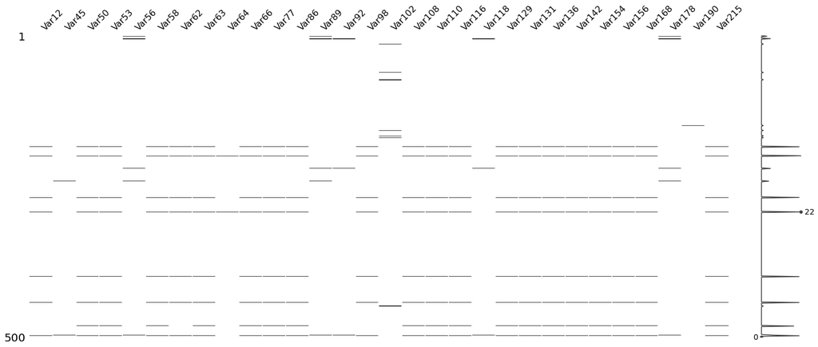

```python
filter_data = msno.nullity_filter(temp_data, filter='bottom',n = 30)
msno.matrix(filter_data.sample(500))
plt.show()
```

The white lines in above figure represent missing data.

Observation:

- You can see there is a patten of missingness of values.

#### Checking for the correlation of missingness

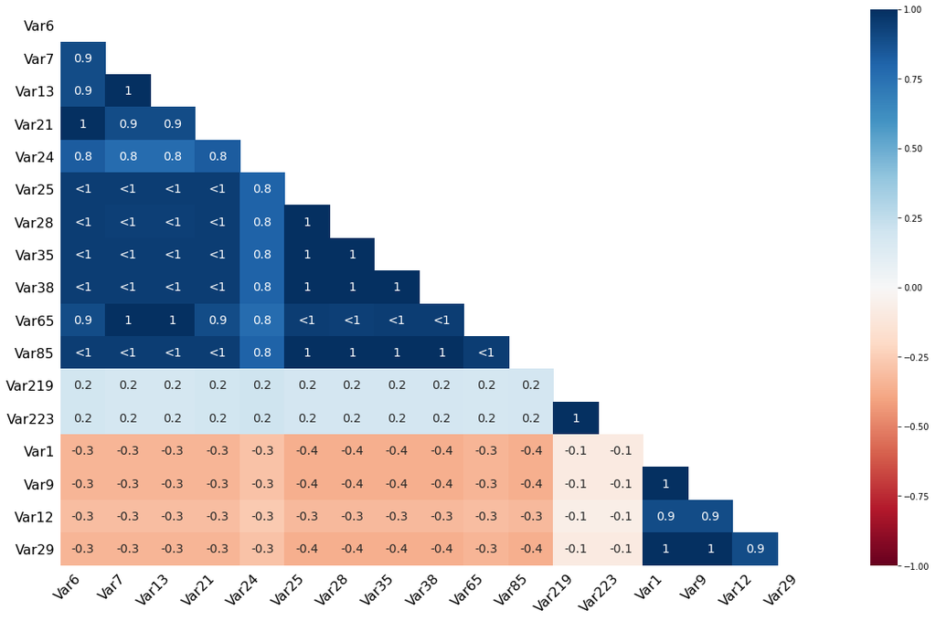

```python
msno.heatmap(temp_data[['Var6','Var7','Var13','Var21','Var24','Var25','Var28','Var35','Var38','Var65','Var85','Var219','Var223','Var1','Var9','Var12','Var29']])
```

We took a handful of features to check whether there is a correlation in missingness of values.

- Nullity correlation ranges from -1 (if one variable appears the other definitely does not) to 0 (variables appearing or not appearing have no effect on one another) to 1 (if one variable appears the other definitely also does).

Observation:

- Most of the features we checked have value 1 meaning there is a correlation in missingness

Conclusion:

- As there is a correlation in missingness, we can rule out Missing Completely at random.

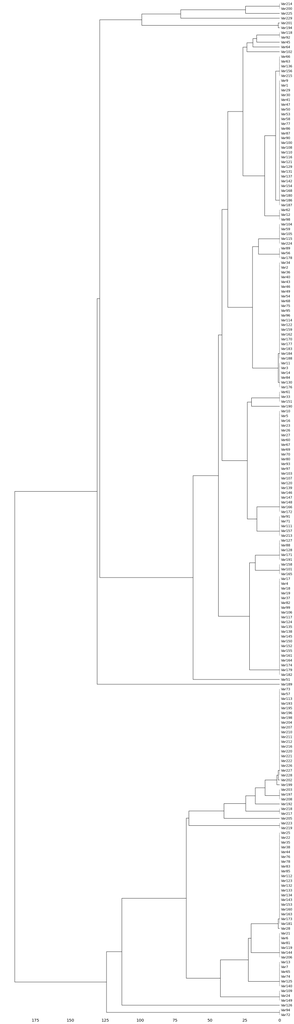

```python
msno.dendrogram(temp_data)
```

Observation:

- Variable value which are linked together at 0 fully predict one another's presence i.e one variable might always be empty when another is filled, or they might always both be filled or both empty, and so on.
- There are lot of variable which are linked at 0 distance.
- You can see from the matrix above that in a feature group there is a pattern of missingness

##### <font color= "red"> Query: how to conclude whether it is MAR (Missing at random) or MNAR(Missing not at random)?

https://www.youtube.com/watch?v=YpqUbirqFxQ

https://www.youtube.com/watch?v=ACN29i_fqkk

https://www.youtube.com/watch?v=asyJCVLV4LI

**To check if the missing data depends on the observed data (MAR), we'll put sub sample of missing data columns against sample of categorical columns with no missing data and see if data is missing for specific categorical value.**

```python
missing_data_cols = ['Var123','Var132','Var133','Var143','Var153','Var160','Var163','Var173','Var181']
#cat_cols = ['Var192','Var193','Var195','Var196','Var197','Var198','Var199','Var202','Var203','Var204']
```

```python
cat_not_nan_cols = not_nan_columns[3:]
```

```python
num_not_nan = not_nan_columns[:3]
```

```python
all_cols = missing_data_cols + list(cat_not_nan_cols)
```

```python
missing_data = X_train_appetency[all_cols]
```

```python
missing_data.head()
```

|  | Var123 | Var132 | Var133 | Var143 | Var153 | Var160 | Var163 | Var173 | Var181 | Var193 | Var195 | Var196 | Var198 | Var204 | Var207 | Var210 | Var211 | Var212 | Var216 | Var220 | Var221 | Var222 | Var226 | Var227 | Var228 |
| --- | --- | --- | --- | --- | --- | --- | --- | --- | --- | --- | --- | --- | --- | --- | --- | --- | --- | --- | --- | --- | --- | --- | --- | --- | --- |
| 1660 | 42.0 | 0.0 | 130690.0 | 0.0 | 160024.0 | 28.0 | 33654.0 | 0.0 | 0.0 | rEUOq2QD1qfkRr6qpua | taul | 1K8T | fhk21Ss | KfYH | 7M47J5GA0pTYIFxg5uy | g5HH | L84s | tbewxY_YSo | XTbq0YX | 4UxGlow | JIiEFBU | catzS2D | me1d | ZI9m | ib5G6X1eUxUn6 |
| 24237 | 0.0 | 0.0 | 0.0 | 0.0 | 21804.0 | 0.0 | 0.0 | 0.0 | 0.0 | RO12 | LfvqpCtLOY | 1K8T | eQgxutV | TjV7 | me75fM6ugJ | uKAI | Mtgm | NhsEn4L | kq00nJM | nJQDBnE | oslk | p1jgRjy | FSa2 | RAYp | F2FyR07IdsN7I |
| 1673 | 24.0 | 0.0 | 60000.0 | 0.0 | 128076.0 | 16.0 | 88896.0 | 0.0 | 0.0 | RO12 | taul | 1K8T | T7ckueW | jdbz | me75fM6ugJ | uKAI | Mtgm | NhsEn4L | mAjbk_S | WZA8iqZ | oslk | jCiQv5o | kwS7 | RAYp | F2FyR07IdsN7I |
| 30043 | NaN | NaN | NaN | NaN | NaN | NaN | NaN | NaN | NaN | RO12 | taul | 1K8T | z7269e2 | xSqs | DHn_WUyBhW_whjA88g9bvA64_ | uKAI | L84s | CrNX | NGZ_12K | VoPunG_ | d0EEeJi | ucmrzUK | szEZ | 02N6s8f | F2FyR07IdsN7I |
| 11297 | 66.0 | 0.0 | 1176270.0 | 0.0 | 1804564.0 | 82.0 | 213090.0 | 0.0 | 0.0 | 2Knk1KF | taul | 1K8T | eDd7wZ4 | TjV7 | me75fM6ugJ | uKAI | L84s | XfqtO3UdzaXh_ | XTbPUYD | t9i0FxM | oslk | YLmz_Kt | FSa2 | RAYp | TCU50_Yjmm6GIBZ0lL_ |

```python
missing_data.isna().any(axis = 1)
```

```
1660     False
24237    False
1673     False
30043     True
11297    False
         ...
32360     True
8271     False
30452    False
26370    False
3279     False
Length: 40000, dtype: bool
```

```python
#https://stackoverflow.com/questions/14247586/how-to-select-rows-with-one-or-more-nulls-from-a-pandas-dataframe-without-listin
missing_data[missing_data.isna().any(axis = 1)][cat_not_nan_cols].nunique()
```

```
Var193       5
Var195       7
Var196       3
Var198    1126
Var204     100
Var207       6
Var210       5
Var211       2
Var212      15
Var216     150
Var220    1126
Var221       7
Var222    1126
Var226      23
Var227       7
Var228      10
dtype: int64
```

**Checking for relation of missingness with numerical data**

```python
num_not_nan
```

```
array(['Var57', 'Var73', 'Var113'], dtype=object)
```

```python
all_cols = missing_data_cols + list(num_not_nan)
```

```python
missing_data = X_train_appetency[all_cols]
```

```python
missing_data.head()
```

|  | Var123 | Var132 | Var133 | Var143 | Var153 | Var160 | Var163 | Var173 | Var181 | Var57 | Var73 | Var113 |
| --- | --- | --- | --- | --- | --- | --- | --- | --- | --- | --- | --- | --- |
| 1660 | 42.0 | 0.0 | 130690.0 | 0.0 | 160024.0 | 28.0 | 33654.0 | 0.0 | 0.0 | 2.917325 | 154 | -1632648.0 |
| 24237 | 0.0 | 0.0 | 0.0 | 0.0 | 21804.0 | 0.0 | 0.0 | 0.0 | 0.0 | 2.773980 | 12 | -1091284.0 |
| 1673 | 24.0 | 0.0 | 60000.0 | 0.0 | 128076.0 | 16.0 | 88896.0 | 0.0 | 0.0 | 2.089297 | 38 | -1915512.0 |
| 30043 | NaN | NaN | NaN | NaN | NaN | NaN | NaN | NaN | NaN | 0.831233 | 8 | -1010148.0 |
| 11297 | 66.0 | 0.0 | 1176270.0 | 0.0 | 1804564.0 | 82.0 | 213090.0 | 0.0 | 0.0 | 1.055330 | 166 | -51767.2 |

**Dropping all nan**

```python
non_missing_data = missing_data.dropna()
```

**Checking min and max**

```python
non_missing_data.min()
```

```
Var123    0.000000e+00
Var132    0.000000e+00
Var133    0.000000e+00
Var143    0.000000e+00
Var153    0.000000e+00
Var160    0.000000e+00
Var163    0.000000e+00
Var173    0.000000e+00
Var181    0.000000e+00
Var57     2.136296e-04
Var73     1.200000e+01
Var113   -9.803600e+06
dtype: float64
```

```python
non_missing_data.max()
```

```
Var123       13086.0
Var132         160.0
Var133    15009900.0
Var143          18.0
Var153    13907800.0
Var160        4862.0
Var163    14515200.0
Var173           6.0
Var181          49.0
Var57            7.0
Var73          264.0
Var113     9932480.0
dtype: float64
```

**Only keeping nan data and then checking min and max of numerical var**

```python
missing = missing_data[missing_data.isna().any(axis =1)].iloc[:,-3:]
```

```python
missing_data[missing_data.isna().any(axis =1)].min()
```

```
Var123             NaN
Var132             NaN
Var133             NaN
Var143             NaN
Var153             NaN
Var160             NaN
Var163             NaN
Var173             NaN
Var181             NaN
Var57     2.136296e-04
Var73     4.000000e+00
Var113   -9.684120e+06
dtype: float64
```

```python
missing_data[missing_data.isna().any(axis =1)].max()
```

```
Var123          NaN
Var132          NaN
Var133          NaN
Var143          NaN
Var153          NaN
Var160          NaN
Var163          NaN
Var173          NaN
Var181          NaN
Var57           7.0
Var73          10.0
Var113    6239680.0
dtype: float64
```

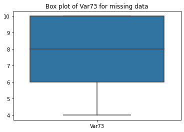

```python
sns.boxplot(data = missing[['Var73']])
plt.title('Box plot of Var73 for missing data')
plt.show()
```

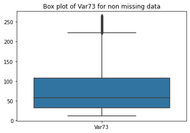

```python
sns.boxplot(data = non_missing_data[['Var73']])
plt.title('Box plot of Var73 for non missing data')
plt.show()
```

Observation:

- For var73, if you look closely for non missing min and max, it is 12 and 264 resp. However max for missing data is 10.

We can say that for the data missing the value of Var73 end at 10 but for data present value of Var73 starts at 12. This may be one of many other cases present in dataset.

Since there is pattern in missingness and a missingness depends on observed data and we can assume that this is **Missing at Random (MAR).**

Now that we have concluded that data is Missing at Random (MAR), we can either remove the NaN data or we can use imputation.

For removing data, we have:

- Listwise deletion : Removes all data from an observation that has one or more missing values. Produces bias
- Pairwise deletion : Used in MCAR.
- Dropping variable : Dropping variables with having missing values % greater than 60%

We'll be dropping variables followed by imputation.

Reference : https://towardsdatascience.com/how-to-handle-missing-data-8646b18db0d4

### Handling NaNs

As we can see from the graph above, most of features have NaN values reaching close to 40k out of 40k datapoints. In order to handle that, we'll be removing features in which NaN value exceeds the threshold. We'll check for 50,60, 70, 80 percent for threshold value.

```python
nan_count_array = np.asarray(nan_count_array)
```

```python
print('Number of features which have NaN count less than 50 perc of original data: ',(nan_count_array < .5*X_train_appetency.shape[0]).sum())
```

```
Number of features which have NaN count less than 50 perc of original data:  69
```

```python
print('Number of features which have NaN count less than 60 perc of original data: ',(nan_count_array < .6*X_train_appetency.shape[0]).sum())
```

```
Number of features which have NaN count less than 60 perc of original data:  74
```

```python
print('Number of features which have NaN count less than 70 perc of original data: ',(nan_count_array < .7*X_train_appetency.shape[0]).sum())
```

```
Number of features which have NaN count less than 70 perc of original data:  74
```

```python
print('Number of features which have NaN count less than 80 perc of original data: ',(nan_count_array < .8*X_train_appetency.shape[0]).sum())
```

```
Number of features which have NaN count less than 80 perc of original data:  76
```

Observation:

- When threshold is set at 50 perc, only 69 features have NaN count less than 50% of total data.
- For both 60 and 70 value of threshold, number of features remains same at 74.
- When threshold is set at 80% , number of features that satify the condition are 76. An increase of two feature from last observation.

We'll continue with 60% threshold and remove features which have NaN count more than 60%

```python
features = np.argwhere(nan_count_array < .6*X_train_appetency.shape[0])
```

```python
features = features.flatten()
```

```python
features
```

```
array([  5,   6,  12,  20,  21,  23,  24,  27,  34,  37,  43,  56,  64,
        71,  72,  73,  75,  77,  80,  82,  84,  93, 108, 111, 112, 118,
       122, 124, 125, 131, 132, 133, 139, 142, 143, 148, 152, 159, 162,
       172, 180, 188, 191, 192, 194, 195, 196, 197, 198, 199, 201, 202,
       203, 204, 205, 206, 207, 209, 210, 211, 213, 215, 216, 217, 218,
       219, 220, 221, 222, 224, 225, 226, 227, 228])
```

```python
data_new = X_train_appetency.iloc[:,features]
data_new_test = X_test_appetency.iloc[:, features]
```

```python
X_test_appetency = X_test_appetency.iloc[:, features]
```

```python
data_new.head()
```

|  | Var6 | Var7 | Var13 | Var21 | Var22 | Var24 | Var25 | Var28 | Var35 | Var38 | Var44 | Var57 | Var65 | Var72 | Var73 | Var74 | Var76 | Var78 | Var81 | Var83 | Var85 | Var94 | Var109 | Var112 | Var113 | Var119 | Var123 | Var125 | Var126 | … |
| --- | --- | --- | --- | --- | --- | --- | --- | --- | --- | --- | --- | --- | --- | --- | --- | --- | --- | --- | --- | --- | --- | --- | --- | --- | --- | --- | --- | --- | --- | --- |
| 1660 | 315.0 | 7.0 | 1900.0 | 96.0 | 120.0 | 2.0 | 8.0 | 100.32 | 0.0 | 22116.0 | 0.0 | 2.917325 | 9.0 | NaN | 154 | 0.0 | 0.0 | 0.0 | 4682.70 | 5.0 | 2.0 | NaN | 8.0 | 0.0 | -1632648.0 | 300.0 | 42.0 | 18846.0 | -22.0 | … |
| 24237 | 0.0 | 0.0 | 0.0 | 12.0 | 15.0 | 0.0 | 24.0 | 238.72 | 0.0 | 0.0 | 0.0 | 2.773980 | 9.0 | NaN | 12 | 0.0 | 0.0 | 0.0 | 5451.00 | 0.0 | 0.0 | NaN | 0.0 | 0.0 | -1091284.0 | 15.0 | 0.0 | 0.0 | -8.0 | … |
| 1673 | 588.0 | 7.0 | 32.0 | 84.0 | 105.0 | 12.0 | 8.0 | 166.56 | 0.0 | 17556.0 | 0.0 | 2.089297 | 9.0 | 3.0 | 38 | 21.0 | 13576.0 | 0.0 | 22959.21 | 5.0 | 4.0 | 53523.0 | 56.0 | 40.0 | -1915512.0 | 295.0 | 24.0 | 1521.0 | -20.0 | … |
| 30043 | NaN | NaN | NaN | NaN | NaN | NaN | NaN | NaN | NaN | NaN | NaN | 0.831233 | NaN | NaN | 8 | NaN | NaN | NaN | NaN | NaN | NaN | NaN | NaN | NaN | -1010148.0 | NaN | NaN | NaN | 4.0 | … |
| 11297 | 3388.0 | 7.0 | 5084.0 | 368.0 | 460.0 | 6.0 | 160.0 | 233.44 | 0.0 | 209742.0 | 0.0 | 1.055330 | 9.0 | 3.0 | 166 | 609.0 | 290736.0 | 0.0 | 7845.99 | 25.0 | 8.0 | 76719.0 | 72.0 | 88.0 | -51767.2 | 2705.0 | 66.0 | 12951.0 | 48.0 | … |

```python
data_new_test.head()
```

|  | Var6 | Var7 | Var13 | Var21 | Var22 | Var24 | Var25 | Var28 | Var35 | Var38 | Var44 | Var57 | Var65 | Var72 | Var73 | Var74 | Var76 | Var78 | Var81 | Var83 | Var85 | Var94 | Var109 | Var112 | Var113 | Var119 | Var123 | Var125 | Var126 | … |
| --- | --- | --- | --- | --- | --- | --- | --- | --- | --- | --- | --- | --- | --- | --- | --- | --- | --- | --- | --- | --- | --- | --- | --- | --- | --- | --- | --- | --- | --- | --- |
| 27046 | NaN | NaN | NaN | NaN | NaN | NaN | NaN | NaN | NaN | NaN | NaN | 6.613117 | NaN | NaN | 6 | NaN | NaN | NaN | NaN | NaN | NaN | NaN | NaN | NaN | -974560.0 | NaN | NaN | NaN | -20.0 | … |
| 39155 | 623.0 | 0.0 | 0.0 | 172.0 | 215.0 | 4.0 | 24.0 | 220.08 | 0.0 | 2831868.0 | 0.0 | 1.439009 | 9.0 | NaN | 26 | 0.0 | 3713992.0 | 0.0 | 160036.2 | 20.0 | 4.0 | NaN | 40.0 | 48.0 | 140786.4 | 690.0 | 60.0 | 0.0 | NaN | … |
| 31402 | NaN | NaN | NaN | NaN | NaN | NaN | NaN | NaN | NaN | NaN | NaN | 6.352703 | NaN | NaN | 4 | NaN | NaN | NaN | NaN | NaN | NaN | NaN | NaN | NaN | -1729624.0 | NaN | NaN | NaN | -20.0 | … |
| 14638 | 651.0 | 7.0 | 3292.0 | 120.0 | 150.0 | 0.0 | 0.0 | 220.08 | 0.0 | 0.0 | 0.0 | 2.941465 | 9.0 | NaN | 106 | 84.0 | 5529600.0 | 0.0 | 160063.2 | 0.0 | 0.0 | NaN | 32.0 | 64.0 | 114931.6 | 490.0 | 0.0 | 58842.0 | NaN | … |
| 5274 | NaN | NaN | NaN | NaN | NaN | NaN | NaN | NaN | NaN | NaN | NaN | 2.307199 | NaN | NaN | 4 | NaN | NaN | NaN | NaN | NaN | NaN | NaN | NaN | NaN | -4337640.0 | NaN | NaN | NaN | -20.0 | … |

```python
#https://www.kaggle.com/questions-and-answers/181332
#http://shakedzy.xyz/dython/modules/nominal/#associations

# nominal.associations(data_new,figsize=(50,50), num_num_assoc= 'spearman',cmap = 'GnBu',mark_columns=True);
```

Observation:

##### <font color = 'red'> Query: Should we remove the highly correlated feature? i.e having corr > 0.8

This answer to this depends on factors like type of algorithm your are considering, interpretability of your results, etc.

Go through this thread once: https://datascience.stackexchange.com/questions/24452/in-supervised-learning-why-is-it-bad-to-have-correlated-features

Depending on the various experiment settings you create, treat the collinear features accordingly

We'll not be removing collinear features as having collinear features may or may not improve model performance but it will not degrade its performance. Also, they may be chance that new features based on these collinear features may add some new information to the model.

#### Feature Groups

##### Plotting means of the features

```python
data_new.info()
```

```
<class 'pandas.core.frame.DataFrame'>
Int64Index: 40000 entries, 1660 to 3279
Data columns (total 74 columns):
 #   Column  Non-Null Count  Dtype
---  ------  --------------  -----
 0   Var6    35583 non-null  float64
 1   Var7    35579 non-null  float64
 2   Var13   35579 non-null  float64
 3   Var21   35583 non-null  float64
 4   Var22   36002 non-null  float64
 5   Var24   34221 non-null  float64
 6   Var25   36002 non-null  float64
 7   Var28   36001 non-null  float64
 8   Var35   36002 non-null  float64
 9   Var38   36002 non-null  float64
```

[output cut: 66 more lines]

```python
numerical_data = data_new.iloc[:,0:42]
numerical_data_test = data_new_test.iloc[:,:42]
```

```python
numerical_data.head()
```

|  | Var6 | Var7 | Var13 | Var21 | Var22 | Var24 | Var25 | Var28 | Var35 | Var38 | Var44 | Var57 | Var65 | Var72 | Var73 | Var74 | Var76 | Var78 | Var81 | Var83 | Var85 | Var94 | Var109 | Var112 | Var113 | Var119 | Var123 | Var125 | Var126 | … |
| --- | --- | --- | --- | --- | --- | --- | --- | --- | --- | --- | --- | --- | --- | --- | --- | --- | --- | --- | --- | --- | --- | --- | --- | --- | --- | --- | --- | --- | --- | --- |
| 1660 | 315.0 | 7.0 | 1900.0 | 96.0 | 120.0 | 2.0 | 8.0 | 100.32 | 0.0 | 22116.0 | 0.0 | 2.917325 | 9.0 | NaN | 154 | 0.0 | 0.0 | 0.0 | 4682.70 | 5.0 | 2.0 | NaN | 8.0 | 0.0 | -1632648.0 | 300.0 | 42.0 | 18846.0 | -22.0 | … |
| 24237 | 0.0 | 0.0 | 0.0 | 12.0 | 15.0 | 0.0 | 24.0 | 238.72 | 0.0 | 0.0 | 0.0 | 2.773980 | 9.0 | NaN | 12 | 0.0 | 0.0 | 0.0 | 5451.00 | 0.0 | 0.0 | NaN | 0.0 | 0.0 | -1091284.0 | 15.0 | 0.0 | 0.0 | -8.0 | … |
| 1673 | 588.0 | 7.0 | 32.0 | 84.0 | 105.0 | 12.0 | 8.0 | 166.56 | 0.0 | 17556.0 | 0.0 | 2.089297 | 9.0 | 3.0 | 38 | 21.0 | 13576.0 | 0.0 | 22959.21 | 5.0 | 4.0 | 53523.0 | 56.0 | 40.0 | -1915512.0 | 295.0 | 24.0 | 1521.0 | -20.0 | … |
| 30043 | NaN | NaN | NaN | NaN | NaN | NaN | NaN | NaN | NaN | NaN | NaN | 0.831233 | NaN | NaN | 8 | NaN | NaN | NaN | NaN | NaN | NaN | NaN | NaN | NaN | -1010148.0 | NaN | NaN | NaN | 4.0 | … |
| 11297 | 3388.0 | 7.0 | 5084.0 | 368.0 | 460.0 | 6.0 | 160.0 | 233.44 | 0.0 | 209742.0 | 0.0 | 1.055330 | 9.0 | 3.0 | 166 | 609.0 | 290736.0 | 0.0 | 7845.99 | 25.0 | 8.0 | 76719.0 | 72.0 | 88.0 | -51767.2 | 2705.0 | 66.0 | 12951.0 | 48.0 | … |

```python
numerical_data_test.head()
```

|  | Var6 | Var7 | Var13 | Var21 | Var22 | Var24 | Var25 | Var28 | Var35 | Var38 | Var44 | Var57 | Var65 | Var72 | Var73 | Var74 | Var76 | Var78 | Var81 | Var83 | Var85 | Var94 | Var109 | Var112 | Var113 | Var119 | Var123 | Var125 | Var126 | … |
| --- | --- | --- | --- | --- | --- | --- | --- | --- | --- | --- | --- | --- | --- | --- | --- | --- | --- | --- | --- | --- | --- | --- | --- | --- | --- | --- | --- | --- | --- | --- |
| 27046 | NaN | NaN | NaN | NaN | NaN | NaN | NaN | NaN | NaN | NaN | NaN | 6.613117 | NaN | NaN | 6 | NaN | NaN | NaN | NaN | NaN | NaN | NaN | NaN | NaN | -974560.0 | NaN | NaN | NaN | -20.0 | … |
| 39155 | 623.0 | 0.0 | 0.0 | 172.0 | 215.0 | 4.0 | 24.0 | 220.08 | 0.0 | 2831868.0 | 0.0 | 1.439009 | 9.0 | NaN | 26 | 0.0 | 3713992.0 | 0.0 | 160036.2 | 20.0 | 4.0 | NaN | 40.0 | 48.0 | 140786.4 | 690.0 | 60.0 | 0.0 | NaN | … |
| 31402 | NaN | NaN | NaN | NaN | NaN | NaN | NaN | NaN | NaN | NaN | NaN | 6.352703 | NaN | NaN | 4 | NaN | NaN | NaN | NaN | NaN | NaN | NaN | NaN | NaN | -1729624.0 | NaN | NaN | NaN | -20.0 | … |
| 14638 | 651.0 | 7.0 | 3292.0 | 120.0 | 150.0 | 0.0 | 0.0 | 220.08 | 0.0 | 0.0 | 0.0 | 2.941465 | 9.0 | NaN | 106 | 84.0 | 5529600.0 | 0.0 | 160063.2 | 0.0 | 0.0 | NaN | 32.0 | 64.0 | 114931.6 | 490.0 | 0.0 | 58842.0 | NaN | … |
| 5274 | NaN | NaN | NaN | NaN | NaN | NaN | NaN | NaN | NaN | NaN | NaN | 2.307199 | NaN | NaN | 4 | NaN | NaN | NaN | NaN | NaN | NaN | NaN | NaN | NaN | -4337640.0 | NaN | NaN | NaN | -20.0 | … |

```python
numerical_data.info()
```

```
<class 'pandas.core.frame.DataFrame'>
Int64Index: 40000 entries, 1660 to 3279
Data columns (total 42 columns):
 #   Column  Non-Null Count  Dtype
---  ------  --------------  -----
 0   Var6    35583 non-null  float64
 1   Var7    35579 non-null  float64
 2   Var13   35579 non-null  float64
 3   Var21   35583 non-null  float64
 4   Var22   36002 non-null  float64
 5   Var24   34221 non-null  float64
 6   Var25   36002 non-null  float64
 7   Var28   36001 non-null  float64
 8   Var35   36002 non-null  float64
 9   Var38   36002 non-null  float64
```

[output cut: 34 more lines]

```python
means = numerical_data.mean()
```

```python
means_test = numerical_data_test.mean()
```

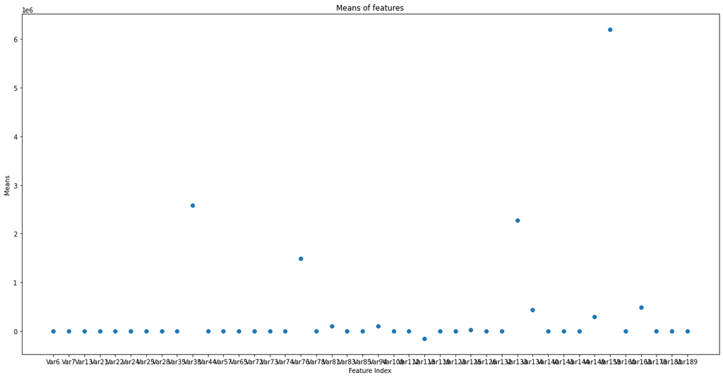

```python
plt.figure(figsize = (20, 10))
plt.scatter(numerical_data.columns,means)
plt.title('Means of features')
plt.xlabel('Feature Index')
plt.ylabel('Means')
plt.show()
```

Observation:

- Most of means on scale are close to 0.
- Only 4 features have mean > 1 million

Let's try again by removing means > 1000000

```python
filter_means = means[means < 1000000]
```

```python
filter_means.shape
```

```
(38,)
```

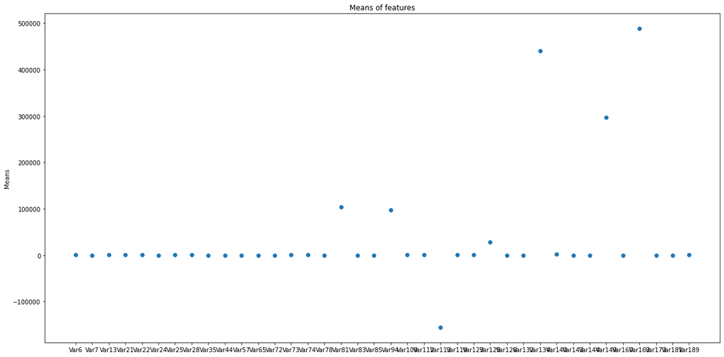

```python
plt.figure(figsize = (20, 10))
plt.scatter(filter_means.index, filter_means)
plt.title('Means of features')
plt.ylabel('Means')
plt.show()
```

Observation:

- Out of 42 numerical features, 38 are under mean of 1 million
- Most of the means are concentrated in region < 1 mil and close to 0

Let's plot region under 10k

```python
filter_means = means[(means < 10000) & (means > 0)]
```

```python
filter_means.shape
```

```
(30,)
```

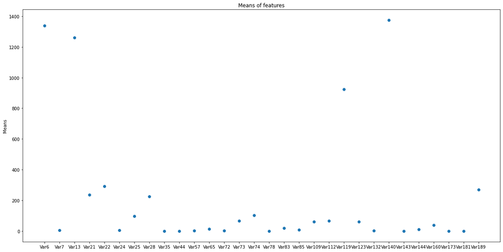

```python
plt.figure(figsize = (20, 10))
plt.scatter(filter_means.index, filter_means)
plt.title('Means of features')
plt.ylabel('Means')
plt.show()
```

Observation:

- There are 30 points which lie under 10k.
- Most of the points are concentrated under 400

let's observation area under mean of 400

```python
filter_means = means[(means < 400) & (means > 0)]
```

```python
filter_means.shape
```

```
(26,)
```

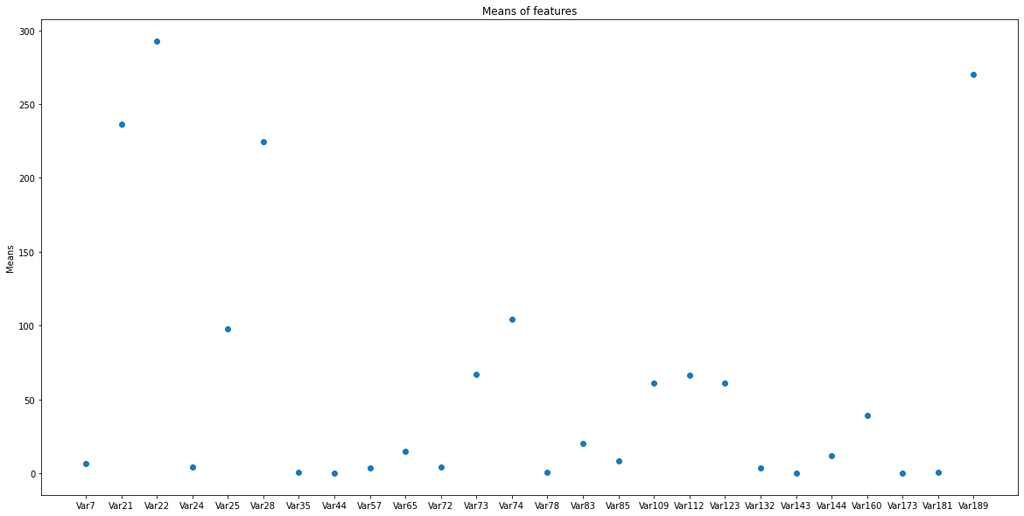

```python
plt.figure(figsize = (20, 10))
plt.scatter(filter_means.index, filter_means)
plt.title('Means of features')
plt.ylabel('Means')
plt.show()
```

Observation:

- Most of the means are concentrated under 50.

```python
filter_means = means[(means < 50) & (means > 0)]
```

```python
filter_means.shape
```

```
(16,)
```

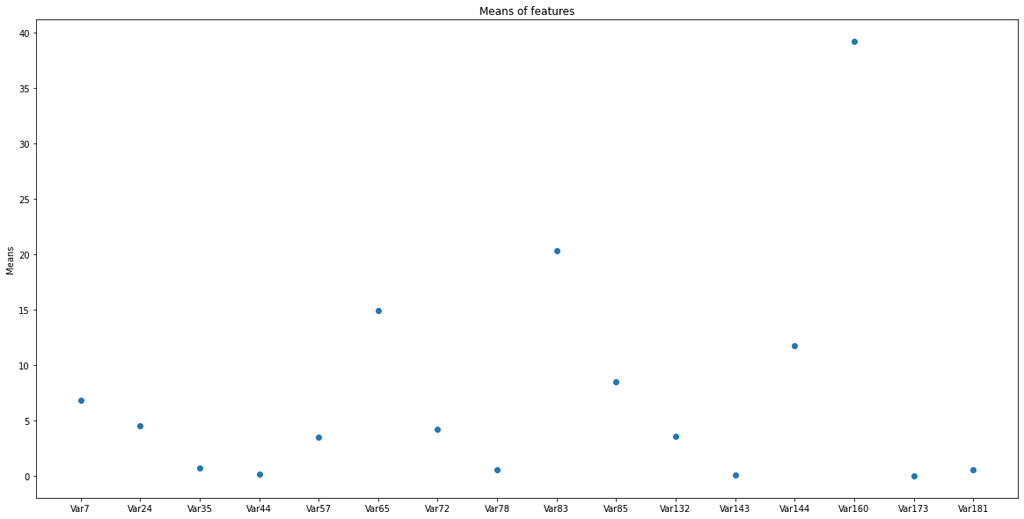

```python
plt.figure(figsize = (20, 10))
plt.scatter(filter_means.index, filter_means)
plt.title('Means of features')
plt.ylabel('Means')
plt.show()
```

Observation:

- Out of 42 numerical features, 26 have mean under 400.
- Out of 42 numerical features, 16 features have mean under 50.
- 14 of the features have mean under 20.

#### <font color= 'red'>Query: How does feature groups help us ?

```
Insight could help you create new features.
```

#### <font color = 'red'>Query: How does means help in identifying feature groups ?

```
We can form a feature group for features having similar means and use that feature group to generate new features. for e.g: a a new feature which is average value of features having mean under 20.
```

```python
means_test
```

```
Var6      1.280190e+03
Var7      6.761202e+00
Var13     1.210703e+03
Var21     2.266976e+02
Var22     2.803243e+02
Var24     4.527547e+00
Var25     9.384804e+01
Var28     2.243610e+02
Var35     6.952942e-01
Var38     2.555882e+06
Var44     1.601958e-01
Var57     3.548064e+00
Var65     1.472608e+01
Var72     4.189055e+00
Var73     6.587980e+01
Var74     1.011020e+02
Var76     1.492063e+06
Var78     5.196351e-01
Var81     1.027725e+05
Var83     1.902047e+01
Var85     8.363110e+00
Var94     1.058181e+05
Var109    6.074348e+01
Var112    6.557615e+01
Var113   -1.425415e+05
Var119    8.828949e+02
Var123    5.699566e+01
Var125    2.717455e+04
Var126   -5.250035e-01
Var132    3.445100e+00
Var133    2.263096e+06
Var134    4.242102e+05
Var140    1.408799e+03
Var143    4.405384e-02
Var144    1.167934e+01
Var149    2.874525e+05
Var153    6.125481e+06
Var160    3.730382e+01
Var163    4.753434e+05
Var173    5.562354e-03
Var181    6.331071e-01
Var189    2.693973e+02
dtype: float64
```

```python
feature_group_200 = means[(means < 200) & (means > 0)]
```

```python
feature_group_200 = list(feature_group_200.index)
```

```python
feature_group_50 = means[(means < 50) & (means > 0)]
```

```python
feature_group_50 = list(feature_group_50.index)
```

```python
with open('feature_group_200.pickle', 'wb') as handle:
    pickle.dump(feature_group_200, handle, protocol=pickle.HIGHEST_PROTOCOL)
```

```python
with open('feature_group_50.pickle', 'wb') as handle:
    pickle.dump(feature_group_50, handle, protocol=pickle.HIGHEST_PROTOCOL)
```

#### Clustering of features

```python
#https://medium.com/analytics-vidhya/gowers-distance-899f9c4bd553
#https://towardsdatascience.com/clustering-datasets-having-both-numerical-and-categorical-variables-ed91cdca0677
```

```python
data_new.head()
```

|  | Var6 | Var7 | Var13 | Var21 | Var22 | Var24 | Var25 | Var28 | Var35 | Var38 | Var44 | Var57 | Var65 | Var72 | Var73 | Var74 | Var76 | Var78 | Var81 | Var83 | Var85 | Var94 | Var109 | Var112 | Var113 | Var119 | Var123 | Var125 | Var126 | … |
| --- | --- | --- | --- | --- | --- | --- | --- | --- | --- | --- | --- | --- | --- | --- | --- | --- | --- | --- | --- | --- | --- | --- | --- | --- | --- | --- | --- | --- | --- | --- |
| 1660 | 315.0 | 7.0 | 1900.0 | 96.0 | 120.0 | 2.0 | 8.0 | 100.32 | 0.0 | 22116.0 | 0.0 | 2.917325 | 9.0 | NaN | 154 | 0.0 | 0.0 | 0.0 | 4682.70 | 5.0 | 2.0 | NaN | 8.0 | 0.0 | -1632648.0 | 300.0 | 42.0 | 18846.0 | -22.0 | … |
| 24237 | 0.0 | 0.0 | 0.0 | 12.0 | 15.0 | 0.0 | 24.0 | 238.72 | 0.0 | 0.0 | 0.0 | 2.773980 | 9.0 | NaN | 12 | 0.0 | 0.0 | 0.0 | 5451.00 | 0.0 | 0.0 | NaN | 0.0 | 0.0 | -1091284.0 | 15.0 | 0.0 | 0.0 | -8.0 | … |
| 1673 | 588.0 | 7.0 | 32.0 | 84.0 | 105.0 | 12.0 | 8.0 | 166.56 | 0.0 | 17556.0 | 0.0 | 2.089297 | 9.0 | 3.0 | 38 | 21.0 | 13576.0 | 0.0 | 22959.21 | 5.0 | 4.0 | 53523.0 | 56.0 | 40.0 | -1915512.0 | 295.0 | 24.0 | 1521.0 | -20.0 | … |
| 30043 | NaN | NaN | NaN | NaN | NaN | NaN | NaN | NaN | NaN | NaN | NaN | 0.831233 | NaN | NaN | 8 | NaN | NaN | NaN | NaN | NaN | NaN | NaN | NaN | NaN | -1010148.0 | NaN | NaN | NaN | 4.0 | … |
| 11297 | 3388.0 | 7.0 | 5084.0 | 368.0 | 460.0 | 6.0 | 160.0 | 233.44 | 0.0 | 209742.0 | 0.0 | 1.055330 | 9.0 | 3.0 | 166 | 609.0 | 290736.0 | 0.0 | 7845.99 | 25.0 | 8.0 | 76719.0 | 72.0 | 88.0 | -51767.2 | 2705.0 | 66.0 | 12951.0 | 48.0 | … |

```python
data_new_test.head()
```

|  | Var6 | Var7 | Var13 | Var21 | Var22 | Var24 | Var25 | Var28 | Var35 | Var38 | Var44 | Var57 | Var65 | Var72 | Var73 | Var74 | Var76 | Var78 | Var81 | Var83 | Var85 | Var94 | Var109 | Var112 | Var113 | Var119 | Var123 | Var125 | Var126 | … |
| --- | --- | --- | --- | --- | --- | --- | --- | --- | --- | --- | --- | --- | --- | --- | --- | --- | --- | --- | --- | --- | --- | --- | --- | --- | --- | --- | --- | --- | --- | --- |
| 27046 | NaN | NaN | NaN | NaN | NaN | NaN | NaN | NaN | NaN | NaN | NaN | 6.613117 | NaN | NaN | 6 | NaN | NaN | NaN | NaN | NaN | NaN | NaN | NaN | NaN | -974560.0 | NaN | NaN | NaN | -20.0 | … |
| 39155 | 623.0 | 0.0 | 0.0 | 172.0 | 215.0 | 4.0 | 24.0 | 220.08 | 0.0 | 2831868.0 | 0.0 | 1.439009 | 9.0 | NaN | 26 | 0.0 | 3713992.0 | 0.0 | 160036.2 | 20.0 | 4.0 | NaN | 40.0 | 48.0 | 140786.4 | 690.0 | 60.0 | 0.0 | NaN | … |
| 31402 | NaN | NaN | NaN | NaN | NaN | NaN | NaN | NaN | NaN | NaN | NaN | 6.352703 | NaN | NaN | 4 | NaN | NaN | NaN | NaN | NaN | NaN | NaN | NaN | NaN | -1729624.0 | NaN | NaN | NaN | -20.0 | … |
| 14638 | 651.0 | 7.0 | 3292.0 | 120.0 | 150.0 | 0.0 | 0.0 | 220.08 | 0.0 | 0.0 | 0.0 | 2.941465 | 9.0 | NaN | 106 | 84.0 | 5529600.0 | 0.0 | 160063.2 | 0.0 | 0.0 | NaN | 32.0 | 64.0 | 114931.6 | 490.0 | 0.0 | 58842.0 | NaN | … |
| 5274 | NaN | NaN | NaN | NaN | NaN | NaN | NaN | NaN | NaN | NaN | NaN | 2.307199 | NaN | NaN | 4 | NaN | NaN | NaN | NaN | NaN | NaN | NaN | NaN | NaN | -4337640.0 | NaN | NaN | NaN | -20.0 | … |

Before we start off with clustering, we need to deal with NaN data. For numerical data, we'll perform mean imputation and for categorical data, we'll consider NaN as separate category.

```python
data_new.info()
```

```
<class 'pandas.core.frame.DataFrame'>
Int64Index: 40000 entries, 1660 to 3279
Data columns (total 74 columns):
 #   Column  Non-Null Count  Dtype
---  ------  --------------  -----
 0   Var6    35583 non-null  float64
 1   Var7    35579 non-null  float64
 2   Var13   35579 non-null  float64
 3   Var21   35583 non-null  float64
 4   Var22   36002 non-null  float64
 5   Var24   34221 non-null  float64
 6   Var25   36002 non-null  float64
 7   Var28   36001 non-null  float64
 8   Var35   36002 non-null  float64
 9   Var38   36002 non-null  float64
```

[output cut: 66 more lines]

```python
data_new.mean()
```

```
Var6      1.337989e+03
Var7      6.821552e+00
Var13     1.259421e+03
Var21     2.364717e+02
Var22     2.927225e+02
Var24     4.503024e+00
Var25     9.757080e+01
Var28     2.245443e+02
Var35     7.221821e-01
Var38     2.584906e+06
Var44     1.684906e-01
Var57     3.503373e+00
Var65     1.490455e+01
Var72     4.191051e+00
Var73     6.683140e+01
Var74     1.042962e+02
Var76     1.489677e+06
Var78     5.384701e-01
Var81     1.031619e+05
Var83     2.027401e+01
Var85     8.485473e+00
Var94     9.692336e+04
Var109    6.092493e+01
Var112    6.638209e+01
Var113   -1.559629e+05
Var119    9.244093e+02
Var123    6.098511e+01
Var125    2.806564e+04
Var126   -5.610034e-01
Var132    3.544470e+00
Var133    2.276188e+06
Var134    4.406187e+05
Var140    1.374385e+03
Var143    6.149658e-02
Var144    1.173974e+01
Var149    2.967865e+05
Var153    6.196071e+06
Var160    3.917732e+01
Var163    4.887582e+05
Var173    7.166269e-03
Var181    6.060497e-01
Var189    2.703276e+02
dtype: float64
```

```python
data_impute = data_new.iloc[:,0:42].fillna(data_new.mean())
```

```python
data_impute_test = data_new_test.iloc[:,0:42].fillna(data_new_test.mean())
```

```python
data_new_imputed = pd.concat([data_impute, data_new.iloc[:,42:].fillna('Others')], axis =1)
```

```python
data_new_imputed_test = pd.concat([data_impute_test, data_new_test.iloc[:,42:].fillna('Others')], axis =1)
```

```python
data_new_imputed.head()
```

|  | Var6 | Var7 | Var13 | Var21 | Var22 | Var24 | Var25 | Var28 | Var35 | Var38 | Var44 | Var57 | Var65 | Var72 | Var73 | Var74 | Var76 | Var78 | Var81 | Var83 | Var85 | Var94 | Var109 | Var112 | Var113 | Var119 | Var123 | Var125 | Var126 | … |
| --- | --- | --- | --- | --- | --- | --- | --- | --- | --- | --- | --- | --- | --- | --- | --- | --- | --- | --- | --- | --- | --- | --- | --- | --- | --- | --- | --- | --- | --- | --- |
| 1660 | 315.000000 | 7.000000 | 1900.000000 | 96.000000 | 120.000000 | 2.000000 | 8.000000 | 100.320000 | 0.000000 | 2.211600e+04 | 0.000000 | 2.917325 | 9.00000 | 4.191051 | 154 | 0.000000 | 0.000000e+00 | 0.00000 | 4682.700000 | 5.000000 | 2.000000 | 96923.364124 | 8.000000 | 0.00000 | -1632648.0 | 300.000000 | 42.000000 | 18846.000000 | -22.0 | … |
| 24237 | 0.000000 | 0.000000 | 0.000000 | 12.000000 | 15.000000 | 0.000000 | 24.000000 | 238.720000 | 0.000000 | 0.000000e+00 | 0.000000 | 2.773980 | 9.00000 | 4.191051 | 12 | 0.000000 | 0.000000e+00 | 0.00000 | 5451.000000 | 0.000000 | 0.000000 | 96923.364124 | 0.000000 | 0.00000 | -1091284.0 | 15.000000 | 0.000000 | 0.000000 | -8.0 | … |
| 1673 | 588.000000 | 7.000000 | 32.000000 | 84.000000 | 105.000000 | 12.000000 | 8.000000 | 166.560000 | 0.000000 | 1.755600e+04 | 0.000000 | 2.089297 | 9.00000 | 3.000000 | 38 | 21.000000 | 1.357600e+04 | 0.00000 | 22959.210000 | 5.000000 | 4.000000 | 53523.000000 | 56.000000 | 40.00000 | -1915512.0 | 295.000000 | 24.000000 | 1521.000000 | -20.0 | … |
| 30043 | 1337.988731 | 6.821552 | 1259.420669 | 236.471686 | 292.722488 | 4.503024 | 97.570802 | 224.544274 | 0.722182 | 2.584906e+06 | 0.168491 | 0.831233 | 14.90455 | 4.191051 | 8 | 104.296242 | 1.489677e+06 | 0.53847 | 103161.865863 | 20.274013 | 8.485473 | 96923.364124 | 60.924929 | 66.38209 | -1010148.0 | 924.409268 | 60.985112 | 28065.637792 | 4.0 | … |
| 11297 | 3388.000000 | 7.000000 | 5084.000000 | 368.000000 | 460.000000 | 6.000000 | 160.000000 | 233.440000 | 0.000000 | 2.097420e+05 | 0.000000 | 1.055330 | 9.00000 | 3.000000 | 166 | 609.000000 | 2.907360e+05 | 0.00000 | 7845.990000 | 25.000000 | 8.000000 | 76719.000000 | 72.000000 | 88.00000 | -51767.2 | 2705.000000 | 66.000000 | 12951.000000 | 48.0 | … |

```python
data_new_imputed_test.head()
```

|  | Var6 | Var7 | Var13 | Var21 | Var22 | Var24 | Var25 | Var28 | Var35 | Var38 | Var44 | Var57 | Var65 | Var72 | Var73 | Var74 | Var76 | Var78 | Var81 | Var83 | Var85 | Var94 | Var109 | Var112 | Var113 | Var119 | Var123 | Var125 | Var126 | … |
| --- | --- | --- | --- | --- | --- | --- | --- | --- | --- | --- | --- | --- | --- | --- | --- | --- | --- | --- | --- | --- | --- | --- | --- | --- | --- | --- | --- | --- | --- | --- |
| 27046 | 1280.190369 | 6.761202 | 1210.703445 | 226.69757 | 280.324285 | 4.527547 | 93.848036 | 224.361049 | 0.695294 | 2.555882e+06 | 0.160196 | 6.613117 | 14.726075 | 4.189055 | 6 | 101.102004 | 1.492063e+06 | 0.519635 | 102772.528613 | 19.020469 | 8.36311 | 105818.06136 | 60.743479 | 65.576149 | -974560.0 | 882.894914 | 56.995661 | 27174.552578 | -20.000000 | … |
| 39155 | 623.000000 | 0.000000 | 0.000000 | 172.00000 | 215.000000 | 4.000000 | 24.000000 | 220.080000 | 0.000000 | 2.831868e+06 | 0.000000 | 1.439009 | 9.000000 | 4.189055 | 26 | 0.000000 | 3.713992e+06 | 0.000000 | 160036.200000 | 20.000000 | 4.00000 | 105818.06136 | 40.000000 | 48.000000 | 140786.4 | 690.000000 | 60.000000 | 0.000000 | -0.525004 | … |
| 31402 | 1280.190369 | 6.761202 | 1210.703445 | 226.69757 | 280.324285 | 4.527547 | 93.848036 | 224.361049 | 0.695294 | 2.555882e+06 | 0.160196 | 6.352703 | 14.726075 | 4.189055 | 4 | 101.102004 | 1.492063e+06 | 0.519635 | 102772.528613 | 19.020469 | 8.36311 | 105818.06136 | 60.743479 | 65.576149 | -1729624.0 | 882.894914 | 56.995661 | 27174.552578 | -20.000000 | … |
| 14638 | 651.000000 | 7.000000 | 3292.000000 | 120.00000 | 150.000000 | 0.000000 | 0.000000 | 220.080000 | 0.000000 | 0.000000e+00 | 0.000000 | 2.941465 | 9.000000 | 4.189055 | 106 | 84.000000 | 5.529600e+06 | 0.000000 | 160063.200000 | 0.000000 | 0.00000 | 105818.06136 | 32.000000 | 64.000000 | 114931.6 | 490.000000 | 0.000000 | 58842.000000 | -0.525004 | … |
| 5274 | 1280.190369 | 6.761202 | 1210.703445 | 226.69757 | 280.324285 | 4.527547 | 93.848036 | 224.361049 | 0.695294 | 2.555882e+06 | 0.160196 | 2.307199 | 14.726075 | 4.189055 | 4 | 101.102004 | 1.492063e+06 | 0.519635 | 102772.528613 | 19.020469 | 8.36311 | 105818.06136 | 60.743479 | 65.576149 | -4337640.0 | 882.894914 | 56.995661 | 27174.552578 | -20.000000 | … |

Since our data contain both categorical and numerical features, we'll first convert our Categorical Data to numerical using ordinal encoding.

```python
encoder = OrdinalEncoder(handle_unknown = 'use_encoded_value', unknown_value = -1)
```

```python
data_new_imputed.iloc[:, 42:].head()
```

|  | Var192 | Var193 | Var195 | Var196 | Var197 | Var198 | Var199 | Var200 | Var202 | Var203 | Var204 | Var205 | Var206 | Var207 | Var208 | Var210 | Var211 | Var212 | Var214 | Var216 | Var217 | Var218 | Var219 | Var220 | Var221 | Var222 | Var223 | Var225 | Var226 | … |
| --- | --- | --- | --- | --- | --- | --- | --- | --- | --- | --- | --- | --- | --- | --- | --- | --- | --- | --- | --- | --- | --- | --- | --- | --- | --- | --- | --- | --- | --- | --- |
| 1660 | 9rAq9at_88 | rEUOq2QD1qfkRr6qpua | taul | 1K8T | lK27 | fhk21Ss | Tg7jjBB | 60P9wLk | ympL | 9_Y1 | KfYH | VpdQ | sYC_ | 7M47J5GA0pTYIFxg5uy | kIsH | g5HH | L84s | tbewxY_YSo | 5zAeq8m | XTbq0YX | wXGg | cJvF | FzaX | 4UxGlow | JIiEFBU | catzS2D | LM8l689qOp | Others | me1d | … |
| 24237 | Qu0TmBQZiT | RO12 | LfvqpCtLOY | 1K8T | iJ4u | eQgxutV | n1zVHpT8NN | Others | 9JQA | 9_Y1 | TjV7 | sJzTlal | IYzP | me75fM6ugJ | kIsH | uKAI | Mtgm | NhsEn4L | Others | kq00nJM | TDYB | UYBR | Others | nJQDBnE | oslk | p1jgRjy | Others | Others | FSa2 | … |
| 1673 | zcROj1KVEH | RO12 | taul | 1K8T | 0Y9G | T7ckueW | y2LIM01bE1 | Others | uFNB | 9_Y1 | jdbz | 09_Q | zm5i | me75fM6ugJ | kIsH | uKAI | Mtgm | NhsEn4L | Others | mAjbk_S | ijVe | UYBR | FzaX | WZA8iqZ | oslk | jCiQv5o | LM8l689qOp | Others | kwS7 | … |
| 30043 | dRavyx7ejg | RO12 | taul | 1K8T | SzjZ | z7269e2 | r83_sZi | Others | oe6C | 9_Y1 | xSqs | VpdQ | Others | DHn_WUyBhW_whjA88g9bvA64_ | kIsH | uKAI | L84s | CrNX | Others | NGZ_12K | 3zCM | cJvF | Others | VoPunG_ | d0EEeJi | ucmrzUK | Others | Others | szEZ | … |
| 11297 | 1KSTmBQxul | 2Knk1KF | taul | 1K8T | PGNs | eDd7wZ4 | glRBFJT8NN | 1qt7Yyi | SxPy | 9_Y1 | TjV7 | VpdQ | y6dw | me75fM6ugJ | kIsH | uKAI | L84s | XfqtO3UdzaXh_ | OSsNfBq | XTbPUYD | DKzw | UYBR | FzaX | t9i0FxM | oslk | YLmz_Kt | LM8l689qOp | kG3k | FSa2 | … |

```python
encoder.fit(data_new_imputed.iloc[:,42:])
```

```
OrdinalEncoder(handle_unknown='use_encoded_value', unknown_value=-1)
```

```python
ordinal_features = encoder.transform(data_new_imputed.iloc[:,42:])
```

```python
ordinal_features_test = encoder.transform(data_new_imputed_test.iloc[:,42:])
```

```python
ordinal_features.shape
```

```
(40000, 32)
```

```python
ordinal_features_test.shape
```

```
(10000, 32)
```

```python
numerical_features = data_new_imputed.iloc[:,0:42].values
numerical_features_test = data_new_imputed_test.iloc[:,0:42].values
```

```python
numerical_features.shape
```

```
(40000, 42)
```

```python
numerical_features_test.shape
```

```
(10000, 42)
```

```python
final_features = np.hstack((numerical_features, ordinal_features))
```

```python
final_features.shape
```

```
(40000, 74)
```

```python
final_features_test = np.hstack((numerical_features_test, ordinal_features_test))
```

```python
final_features_test.shape
```

```
(10000, 74)
```

#### Clustering of points

Reference: https://towardsdatascience.com/how-to-create-new-features-using-clustering-4ae772387290

```python
train_labels = []
test_labels = []
for i in range(2,7):
    kmeans = KMeans(n_clusters=i, n_jobs = -1)
    kmeans.fit(final_features)
    train_labels.append(kmeans.labels_)
    test_labels.append(kmeans.predict(final_features_test))
```

```python
# embedded_features = TSNE(n_jobs = -1).fit_transform(final_features)
```

```python
# for i in range(5):
#     plt.figure(figsize = (20,20))
#     plt.scatter(embedded_features[:,0], embedded_features[:,1], c= labels[i])
#     plt.title('Clustering of Features. Number of cluster: {}'.format(i+2))
#     plt.show()
```

Observation:

We will use this cluster label as new feature.

##### <font color = 'red'> Query: How does clustering help in feature group?

you can assign cluster numbers to similar features (groups) to create a new feature. Some more areas can also be explored.

#### Finding Duplicate features

```python
#https://towardsdatascience.com/the-fastml-guide-9ada1bb761cf
duplicate_features = get_duplicate_features(data_new)
```

```python
duplicate_features.head()
```

|  | Desc | feature1 | feature2 |
| --- | --- | --- | --- |
| 0 | Duplicate Index | Var198 | Var220 |
| 1 | Duplicate Index | Var198 | Var222 |
| 2 | Duplicate Index | Var220 | Var222 |

From the Description, we can see that although the values of two features are different but they occur at same index. Let's print them and see.

```python
data_new[data_new.Var198 == 'NldASpP'][['Var198','Var220','Var222']]
```

|  | Var198 | Var220 | Var222 |
| --- | --- | --- | --- |
| 21672 | NldASpP | JFM1BiF | NKv4yOc |
| 28761 | NldASpP | JFM1BiF | NKv4yOc |
| 2322 | NldASpP | JFM1BiF | NKv4yOc |
| 36377 | NldASpP | JFM1BiF | NKv4yOc |
| 17160 | NldASpP | JFM1BiF | NKv4yOc |
| ... | ... | ... | ... |
| 16980 | NldASpP | JFM1BiF | NKv4yOc |
| 40437 | NldASpP | JFM1BiF | NKv4yOc |
| 15538 | NldASpP | JFM1BiF | NKv4yOc |
| 46360 | NldASpP | JFM1BiF | NKv4yOc |
| 156 | NldASpP | JFM1BiF | NKv4yOc |

62 rows × 3 columns

```python
data_new[data_new.Var198 == 'ka_ns41'][['Var198','Var220','Var222']]
```

|  | Var198 | Var220 | Var222 |
| --- | --- | --- | --- |
| 22975 | ka_ns41 | 1YVfGrO | fXVEsaq |
| 45573 | ka_ns41 | 1YVfGrO | fXVEsaq |
| 38111 | ka_ns41 | 1YVfGrO | fXVEsaq |
| 21125 | ka_ns41 | 1YVfGrO | fXVEsaq |
| 35984 | ka_ns41 | 1YVfGrO | fXVEsaq |
| ... | ... | ... | ... |
| 45798 | ka_ns41 | 1YVfGrO | fXVEsaq |
| 24143 | ka_ns41 | 1YVfGrO | fXVEsaq |
| 31825 | ka_ns41 | 1YVfGrO | fXVEsaq |
| 16834 | ka_ns41 | 1YVfGrO | fXVEsaq |
| 16947 | ka_ns41 | 1YVfGrO | fXVEsaq |

95 rows × 3 columns

##### Observation:

- Although we didn't find any duplicate features but there are 3 features for which value are different but they have same mapping.
- For ex: For column Var198, value 'ka_ns41' always occur with '1YVfGrO' (Var220) and 'fXVEsaq' (Var222)

#### <font color = 'red'> Query: Do we remove features with values having same mapping. If so, why?

The duplicate columns could be dropped Because they are the same things

#### Dropping Var220 and Var222

```python
data_new = data_new.drop(['Var220','Var222'], axis = 1)
```

```python
data_new.shape
```

```
(40000, 72)
```

```python
X_test_appetency =  X_test_appetency.drop(['Var220','Var222'], axis = 1)
```

```python
X_test_appetency.shape
```

```
(10000, 72)
```

2 columns have been dropped from dataset. We're left with 72 features now instead of 74

### Saving data in pickle file

```python
with open('X_train_appetency.pickle', 'wb') as handle:
    pickle.dump(data_new, handle, protocol=pickle.HIGHEST_PROTOCOL)
```

```python
with open('y_train_appetency.pickle', 'wb') as handle:
    pickle.dump(y_train_appetency, handle, protocol=pickle.HIGHEST_PROTOCOL)
```

```python
with open('X_test_appetency.pickle', 'wb') as handle:
    pickle.dump(X_test_appetency, handle, protocol=pickle.HIGHEST_PROTOCOL)
```

```python
with open('y_test_appetency.pickle', 'wb') as handle:
    pickle.dump(y_test_appetency, handle, protocol=pickle.HIGHEST_PROTOCOL)
```

```python
with open('train_labels.pickle', 'wb') as handle:
    pickle.dump(train_labels, handle, protocol=pickle.HIGHEST_PROTOCOL)
```

```python
with open('test_labels.pickle', 'wb') as handle:
    pickle.dump(test_labels, handle, protocol=pickle.HIGHEST_PROTOCOL)
```